# Concessão de Crédito

Preparação, Manipualação e Exploração dos dados

# 1 Objetivos

- Tipo de variáveis
  - - Inteiras ou discretas:
  - - Numéricas ou double
  - - Categóricas
  - - Qualitativas
  - Qualidade dos dados
  - - Quantidade de NA’s por variável
- Criação de novas variáveis, se precisar
- Transformação das variáveis, se precisar

# 2 Conjunto de Dados de Teste

```r
df <- data.table::fread('../dados/dataset.csv',
                             sep=",",
                             showProgress = FALSE)  %>%
            data.frame(stringsAsFactors = F)
```

## 2.1 Visualizando os dados

```r
df %>% head()
```

|  | Loan_ID | Gender | Married | Dependents | Education | Self_Employed | ApplicantIncome | CoapplicantIncome | LoanAmount | Loan_Amount_Term | Credit_History | Property_Area | Loan_Status |
| --- | --- | --- | --- | --- | --- | --- | --- | --- | --- | --- | --- | --- | --- |
| 1 | LP001002 | Male | No | 0 | Graduate | No | 5849 | 0 | NA | 360 | 1 | Urban | Y |
| 2 | LP001003 | Male | Yes | 1 | Graduate | No | 4583 | 1508 | 128 | 360 | 1 | Rural | N |
| 3 | LP001005 | Male | Yes | 0 | Graduate | Yes | 3000 | 0 | 66 | 360 | 1 | Urban | Y |
| 4 | LP001006 | Male | Yes | 0 | Not Graduate | No | 2583 | 2358 | 120 | 360 | 1 | Urban | Y |
| 5 | LP001008 | Male | No | 0 | Graduate | No | 6000 | 0 | 141 | 360 | 1 | Urban | Y |
| 6 | LP001011 | Male | Yes | 2 | Graduate | Yes | 5417 | 4196 | 267 | 360 | 1 | Urban | Y |

## 2.2 Qualidade do dados

```r
apply(df,2,function(x) sum(as.numeric(x=="")))
```

```
##           Loan_ID            Gender           Married        Dependents
##                 0                13                 3                15
##         Education     Self_Employed   ApplicantIncome CoapplicantIncome
##                 0                32                 0                 0
##        LoanAmount  Loan_Amount_Term    Credit_History     Property_Area
##                NA                NA                NA                 0
##       Loan_Status
##                 0
```

Observe que as variáveis Gender, Married, Dependents e Self_Employed possuem valores não declarados. Para esses valores irei criar a categoria **vnd** (valor não declarado).

```r
df$Gender[df$Gender == ""] = 'vnd'
df$Married[df$Married == ""] = 'vnd'
df$Dependents[df$Dependents == ""] = 'vnd'
df$Self_Employed[df$Self_Employed == ""] = 'vnd'
```

# 3 Características do Dados

```r
str(df)
```

```
## 'data.frame':    614 obs. of  13 variables:
##  $ Loan_ID          : chr  "LP001002" "LP001003" "LP001005" "LP001006" ...
##  $ Gender           : chr  "Male" "Male" "Male" "Male" ...
##  $ Married          : chr  "No" "Yes" "Yes" "Yes" ...
##  $ Dependents       : chr  "0" "1" "0" "0" ...
##  $ Education        : chr  "Graduate" "Graduate" "Graduate" "Not Graduate" ...
##  $ Self_Employed    : chr  "No" "No" "Yes" "No" ...
##  $ ApplicantIncome  : int  5849 4583 3000 2583 6000 5417 2333 3036 4006 12841 ...
##  $ CoapplicantIncome: num  0 1508 0 2358 0 ...
##  $ LoanAmount       : int  NA 128 66 120 141 267 95 158 168 349 ...
##  $ Loan_Amount_Term : int  360 360 360 360 360 360 360 360 360 360 ...
##  $ Credit_History   : int  1 1 1 1 1 1 1 0 1 1 ...
##  $ Property_Area    : chr  "Urban" "Rural" "Urban" "Urban" ...
##  $ Loan_Status      : chr  "Y" "N" "Y" "Y" ...
```

Há em nosso conjunto de dados 614 linhas e 13 colunas com 3 tipos de dados:

- Character (chr)
- Integer (int)
- Numéric (num)

## 3.1 Dados Duplicados

Será que há dados duplicatos em nosso dataframe?

```r
df %>% distinct(Loan_ID, .keep_all = TRUE)
```

| Loan_ID | Gender | Married | Dependents | Education | Self_Employed | ApplicantIncome | CoapplicantIncome | LoanAmount | Loan_Amount_Term | Credit_History | Property_Area | Loan_Status |
| --- | --- | --- | --- | --- | --- | --- | --- | --- | --- | --- | --- | --- |
| LP001002 | Male | No | 0 | Graduate | No | 5849 | 0.00 | NA | 360 | 1 | Urban | Y |
| LP001003 | Male | Yes | 1 | Graduate | No | 4583 | 1508.00 | 128 | 360 | 1 | Rural | N |
| LP001005 | Male | Yes | 0 | Graduate | Yes | 3000 | 0.00 | 66 | 360 | 1 | Urban | Y |
| LP001006 | Male | Yes | 0 | Not Graduate | No | 2583 | 2358.00 | 120 | 360 | 1 | Urban | Y |
| LP001008 | Male | No | 0 | Graduate | No | 6000 | 0.00 | 141 | 360 | 1 | Urban | Y |
| LP001011 | Male | Yes | 2 | Graduate | Yes | 5417 | 4196.00 | 267 | 360 | 1 | Urban | Y |
| LP001013 | Male | Yes | 0 | Not Graduate | No | 2333 | 1516.00 | 95 | 360 | 1 | Urban | Y |
| LP001014 | Male | Yes | 3+ | Graduate | No | 3036 | 2504.00 | 158 | 360 | 0 | Semiurban | N |
| LP001018 | Male | Yes | 2 | Graduate | No | 4006 | 1526.00 | 168 | 360 | 1 | Urban | Y |
| LP001020 | Male | Yes | 1 | Graduate | No | 12841 | 10968.00 | 349 | 360 | 1 | Semiurban | N |

[output cut: 604 more lines]

Não há linhas duplicatas em nosso conjunto de dados.

# 4 Distribuição das Variáveis Respostas

## 4.1 Variável Loan_Status

Qual a proporção de clientes que pagaram (Y) ou não pagaram (N) os empréstimos?

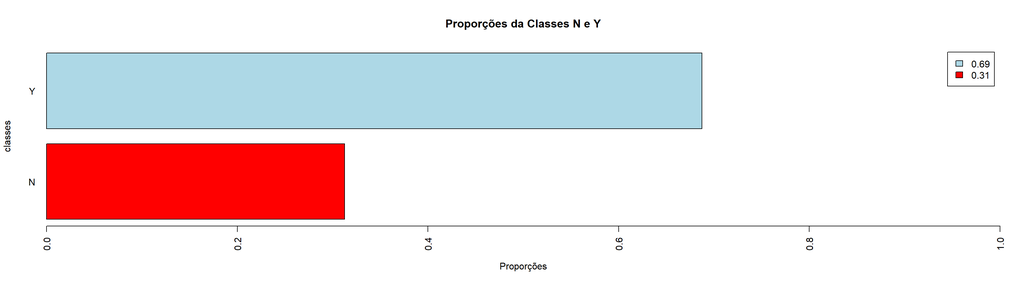

```r
df %>%
  select(Loan_Status) %>%
  table %>%
  prop.table() %>%
  barplot(beside= T,
          main = 'Proporções da Classes N e Y',
          xlab = 'Proporções',
          ylab = 'classes',
          col = c('red','lightblue'),
          horiz = T,
          las = 2,
          xlim = c(0,1),
          legend.text = c(0.31,0.69))
```

Observe que embora as proporções das classes N e Y não estão em perfeito equilíbrio $50\%/50\%$ não há também um desbalanceamento crítico do tipo $90\%/10\%$ ou até $99\%/1\%$ e este fato pode nos ajudar em relação a atingir uma boa performance do modelo.

## 4.2 Variável LoanAmount

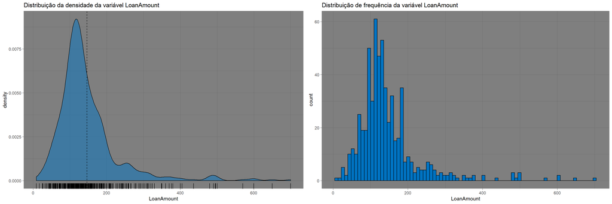

```r
p0 <- ggdensity(df, x = 'LoanAmount',
          fill = "#0073C2FF", color = "black",
          add = "mean", rug = TRUE) +
          labs(title = 'Distribuição da densidade da variável LoanAmount') +
          theme_dark()

p1 <- ggplot(df, aes(x = LoanAmount)) +
      geom_histogram(bins = 80,
                     color = "black",
                     fill = "#0073C2FF") +
      labs(title = 'Distribuição de frequência da variável LoanAmount') +
      theme_dark()


gridExtra::grid.arrange(p0,p1,nrow = 1)
```

## 4.3 Variáreis do Tipo String

Irei converter as variáveis do tipo string para o tipo categórico.

```r
df[,unlist(lapply(df,is.character))] = df[,unlist(lapply(df,is.character))] %>%
                                                         apply(2,as.factor) %>%
                                                         data.frame()
df %>% head()
```

|  | Loan_ID | Gender | Married | Dependents | Education | Self_Employed | ApplicantIncome | CoapplicantIncome | LoanAmount | Loan_Amount_Term | Credit_History | Property_Area | Loan_Status |
| --- | --- | --- | --- | --- | --- | --- | --- | --- | --- | --- | --- | --- | --- |
| 1 | LP001002 | Male | No | 0 | Graduate | No | 5849 | 0 | NA | 360 | 1 | Urban | Y |
| 2 | LP001003 | Male | Yes | 1 | Graduate | No | 4583 | 1508 | 128 | 360 | 1 | Rural | N |
| 3 | LP001005 | Male | Yes | 0 | Graduate | Yes | 3000 | 0 | 66 | 360 | 1 | Urban | Y |
| 4 | LP001006 | Male | Yes | 0 | Not Graduate | No | 2583 | 2358 | 120 | 360 | 1 | Urban | Y |
| 5 | LP001008 | Male | No | 0 | Graduate | No | 6000 | 0 | 141 | 360 | 1 | Urban | Y |
| 6 | LP001011 | Male | Yes | 2 | Graduate | Yes | 5417 | 4196 | 267 | 360 | 1 | Urban | Y |

## 4.4 Resumo das Informações

```r
suppressWarnings(skimr::skim_to_wide(df))
```

Data summary

| Name | .data |
| --- | --- |
| Number of rows | 614 |
| Number of columns | 13 |
| _______________________ |  |
| Column type frequency: |  |
| factor | 8 |
| numeric | 5 |
| ________________________ |  |
| Group variables | None |

**Variable type: factor**

| skim_variable | n_missing | complete_rate | ordered | n_unique | top_counts |
| --- | --- | --- | --- | --- | --- |
| Loan_ID | 0 | 1 | FALSE | 614 | LP0: 1, LP0: 1, LP0: 1, LP0: 1 |
| Gender | 0 | 1 | FALSE | 3 | Mal: 489, Fem: 112, vnd: 13 |
| Married | 0 | 1 | FALSE | 3 | Yes: 398, No: 213, vnd: 3 |
| Dependents | 0 | 1 | FALSE | 5 | 0: 345, 1: 102, 2: 101, 3+: 51 |
| Education | 0 | 1 | FALSE | 2 | Gra: 480, Not: 134 |
| Self_Employed | 0 | 1 | FALSE | 3 | No: 500, Yes: 82, vnd: 32 |
| Property_Area | 0 | 1 | FALSE | 3 | Sem: 233, Urb: 202, Rur: 179 |
| Loan_Status | 0 | 1 | FALSE | 2 | Y: 422, N: 192 |

**Variable type: numeric**

| skim_variable | n_missing | complete_rate | mean | sd | p0 | p25 | p50 | p75 | p100 | hist |
| --- | --- | --- | --- | --- | --- | --- | --- | --- | --- | --- |
| ApplicantIncome | 0 | 1.00 | 5403.46 | 6109.04 | 150 | 2877.5 | 3812.5 | 5795.00 | 81000 | ▇▁▁▁▁ |
| CoapplicantIncome | 0 | 1.00 | 1621.25 | 2926.25 | 0 | 0.0 | 1188.5 | 2297.25 | 41667 | ▇▁▁▁▁ |
| LoanAmount | 22 | 0.96 | 146.41 | 85.59 | 9 | 100.0 | 128.0 | 168.00 | 700 | ▇▃▁▁▁ |
| Loan_Amount_Term | 14 | 0.98 | 342.00 | 65.12 | 12 | 360.0 | 360.0 | 360.00 | 480 | ▁▁▁▇▁ |
| Credit_History | 50 | 0.92 | 0.84 | 0.36 | 0 | 1.0 | 1.0 | 1.00 | 1 | ▂▁▁▁▇ |

Notem que há valores missing presente nas seguintes variáveis:

| Variável | Tipo | Qtde Missing |
| --- | --- | --- |
| Credit_History | Integer | 50 |
| Loan_Amount_Term | Integer | 14 |
| LoanAmount | Integer | 22 |

Irei observar cada uma dessas variáveis e a sua relação com a variável resposta.

# 5 Análise da distribuição para os Valores Missing

Queremos observar aqui qual o comportamento da variável resposta considerando os valores missing das variáveis explicativas.

## 5.1 Variável Credit_History

Vejam que interessante, a variável **Credit_History** tem a característíca de uma variável categórico, no entanto, o seu tipo de dados é integer.

```r
count(df,Credit_History)
```

| Credit_History | n |
| --- | --- |
| 0 | 89 |
| 1 | 475 |
| NA | 50 |

Exatamente como havia pensado! Ela possui apenas dois valores 0 e 1 e dessa forma podemos transforma-la em uma variável categórica sem perda de informção.

```r
df$Credit_History = as.factor(df$Credit_History)
```

Observe que agora variável é do tipo categórico (factor).

```r
df %>% head()
```

|  | Loan_ID | Gender | Married | Dependents | Education | Self_Employed | ApplicantIncome | CoapplicantIncome | LoanAmount | Loan_Amount_Term | Credit_History | Property_Area | Loan_Status |
| --- | --- | --- | --- | --- | --- | --- | --- | --- | --- | --- | --- | --- | --- |
| 1 | LP001002 | Male | No | 0 | Graduate | No | 5849 | 0 | NA | 360 | 1 | Urban | Y |
| 2 | LP001003 | Male | Yes | 1 | Graduate | No | 4583 | 1508 | 128 | 360 | 1 | Rural | N |
| 3 | LP001005 | Male | Yes | 0 | Graduate | Yes | 3000 | 0 | 66 | 360 | 1 | Urban | Y |
| 4 | LP001006 | Male | Yes | 0 | Not Graduate | No | 2583 | 2358 | 120 | 360 | 1 | Urban | Y |
| 5 | LP001008 | Male | No | 0 | Graduate | No | 6000 | 0 | 141 | 360 | 1 | Urban | Y |
| 6 | LP001011 | Male | Yes | 2 | Graduate | Yes | 5417 | 4196 | 267 | 360 | 1 | Urban | Y |

## 5.2 Variável Credit_History vs Loan_Status

Como se comporta a variável resposta **Loan_Status** para os valores missing da variável **Credit_History**?

```r
df[is.na(df$Credit_History),] %>%
          select(Loan_Status) %>%
                        table %>%
                     prop.table()
```

```
## .
##    N    Y
## 0.26 0.74
```

Sabemos que a proporção original das categorias da variável resposta é de 31% para N e de 69% para Y, considerando este fato e observando que os valores ausentes na variável **Credit_History** se aproximam dessa distribuição, temos que, os valores ausentes na **Credit_History** aparentemente não alteram a distribuição da variável resposta.

## 5.3 Variável Credit_History vs LoanAmount

Qual será distribuição da variável **LoanAmount** considerando os valores missing da variável **Credit_History**?

```r
rbind("df" = summary(df$LoanAmount),
      "df.missing" = summary(df[is.na(df$Credit_History),'LoanAmount'])) %>% data.frame()
```

|  | Min. | X1st.Qu. | Median | Mean | X3rd.Qu. | Max. | NA.s |
| --- | --- | --- | --- | --- | --- | --- | --- |
| df | 9 | 100 | 128 | 146.4122 | 168 | 700 | 22 |
| df.missing | 58 | 99 | 130 | 161.0816 | 185 | 650 | 1 |

Os valores para a medida de posição mediana sugere que a distribuição da variável **LoanAmount** é pouco alterada para os valores missing da variável **Credit_History**.

## 5.4 Variável Loan_Amount_Term vs Loan_Status

Qual será a distribuição da variável **Loan_Status** considerando os valores missing da variável **Loan_Amount_Term**?

```r
df[is.na(df$Loan_Amount_Term),] %>%
            select(Loan_Status) %>%
                          table %>%
                      prop.table()
```

```
## .
##         N         Y
## 0.4285714 0.5714286
```

Note que para os valores missing da variável **Loan_Amount_Term** a variável **Loan_Status** tem suas proporções alteradas.

## 5.5 Variável Loan_Amount_Term vs LoanAmount

Qual será distribuição da variável **LoanAmount** considerando os valores missing da variável **Loan_Amount_Term**?

```r
rbind("df" = summary(df$LoanAmount),
      "Loan_Amount_Term_Missing" = summary(df[is.na(df$Loan_Amount_Term),'LoanAmount'])) %>% data.frame()
```

[output not shown]

Novamente temos que os valores missing da variável **Loan_Amount_Term** alteram as características da distribuição da variável **LoanAmount**.

## 5.6 A Variável LoanAmount vs Loan_Status

Distribuição da variável **Loan_Status** considerando os valores missing da variável **LoanAmount**.

```r
df[is.na(df$LoanAmount),] %>%
            select(Loan_Status) %>%
                          table %>%
                      prop.table()
```

```
## .
##   N   Y
## 0.5 0.5
```

Os valores missing da variável **LoanAmount** alteraram as proporções das classes N e Y da variável **Loan_Status**.

# 6 Resolvendo os valores Missing

Para construir um modelo que impute valores nas variáveis com valores missing vamos retirar todas as variáveis que possuem alguma porcentagem de valores nulos e deixar no data frame somente uma delas em cada modelo.

## 6.1 Criando os data frames

Retirando as variáveis **Loan_Amount_Term** e **LoanAmount**.

```r
df.Credit_History <- df %>% select(-Loan_Amount_Term,-LoanAmount)
```

Retirando as variáveis **Credit_History** e **LoanAmount**.

```r
df.Loan_Amount_Term <- df %>% select(-Credit_History,-LoanAmount)
```

Retirando as variáveis **Credit_History** e **Loan_Amount_Term**.

```r
df.LoanAmount <- df %>% select(-Credit_History,-Loan_Amount_Term)
```

Criando um vetor com o nome das variáveis e uma lista com os dataframes criados.

```r
vars <- c('Loan_Amount_Term','Credit_History','LoanAmount')

list.df <- list(df.Loan_Amount_Term,
                df.Credit_History,
                df.LoanAmount)
```

A função abaixo automatiza o processo de impute de dados nos valores missing de cada variável.

```r
f.pred <- function(fac,df.var,rf.model,var){

  new.df <- df.var[is.na(df.var[,var]),!(names(df.var) %in% var)]
  pred_rf <- predict(rf.model, newdata =  new.df)
  fac[is.na(fac[,var]),var] <- pred_rf

  return(fac)
}
```

## 6.2 Usando a Caret e RandomForest

Utilizarei o random forest para o processo de regressão e classifição de imputs dos dados faltantes.

```r
set.seed(12345)

# Para usar no modelo de Imput by Regression
fitControl_a <- trainControl(method="cv",
                           number=5,
                           savePredictions = 'final')

# Para usar no modelo de Imput by classfication
fitControl_b <- trainControl(method="cv",
                           number=5,
                           savePredictions = 'final',
                           classProbs= F,
                           summaryFunction = multiClassSummary)
```

Imputando valores não nulos para em cada variável.

```r
dfa = df
set.seed(12345)

# Crio uma lista para armazenar os modelos
rf.list <- list()

for(j in 1:length(vars)){

 # atribuo em df um df."variavel" sem os valor nulos
 dfx <- list.df[[j]] %>% na.omit()

 # train model regressin with random-forest
 if( vars[j] %in% vars[c(1,3)] ){

     rf.list[[j]] <- caret::train(eval(parse(text = paste(vars[j],'~.'))),
                                                    data = dfx[,-1],
                                                    tuneLength=5,
                                                    trControl = fitControl_a,
                                                    method='rf')
 }


  # train model classification with random-forest
 if( vars[j] %in% vars[2] ){

     rf.list[[j]] <- caret::train(eval(parse(text = paste(vars[j],'~.'))),
                                                    data = dfx[,-1],
                                                    tuneLength=5,
                                                    trControl = fitControl_b,
                                                    method='rf')
 }
 # imputo as categorias faltantes no valores nulos das variáveis
 dfa <- f.pred(dfa,list.df[[j]],rf.list[[j]],vars[j])

 cat(j,' - ')

}
```

```
## 1  - 2  - 3  -
```

Será que há ainda algum valor nulo no conjunto de dados?

```r
anyNA(dfa)
```

```
## [1] FALSE
```

Imputs realizados com sucesso!

# 7 Comparando Distribuições

E como será que ficou a distribuição das variáveis após o imput?

Conjunto de dados originais

```r
summary(df[,vars])
```

```
##  Loan_Amount_Term Credit_History   LoanAmount
##  Min.   : 12      0   : 89       Min.   :  9.0
##  1st Qu.:360      1   :475       1st Qu.:100.0
##  Median :360      NA's: 50       Median :128.0
##  Mean   :342                     Mean   :146.4
##  3rd Qu.:360                     3rd Qu.:168.0
##  Max.   :480                     Max.   :700.0
##  NA's   :14                      NA's   :22
```

Conjunto de dados após os Imputs.

```r
summary(dfa[,vars])
```

```
##  Loan_Amount_Term Credit_History   LoanAmount
##  Min.   : 12      0: 89          Min.   :  9.0
##  1st Qu.:360      1:525          1st Qu.:100.0
##  Median :360                     Median :128.0
##  Mean   :342                     Mean   :146.6
##  3rd Qu.:360                     3rd Qu.:168.0
##  Max.   :480                     Max.   :700.0
```

## 7.1 Analytic Base Table (ABT)

```r
df = dfa
```

# 8 Importância das Variáveis

Será que os dados que possuem valores nulos tem importância em relação as variáveis respostas Loan_Status e LoanAmount?

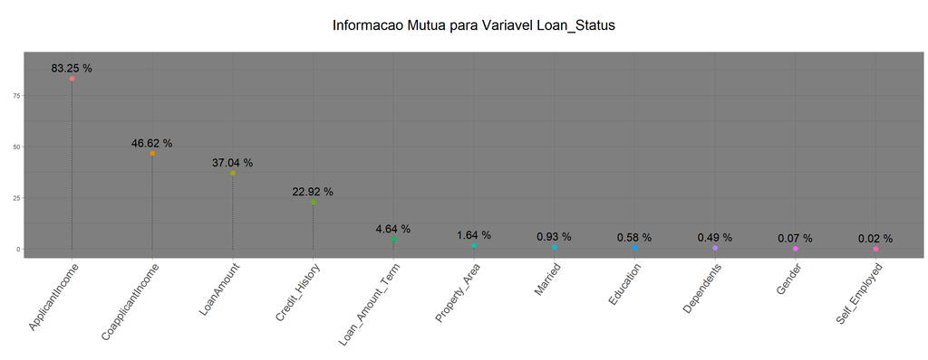

```r
importance.vars(df[,-1],'Loan_Status')
```

Segundo o gráfico acima as variáveis de maior importância para explicar a variável **Loan_Status**, são:

- ApplicationIncome: Renda
- CoapplicationIncome: Renda familiar
- Loan Amount: Quantidade do empréstimo (em milhares)
- Credit_History: Se a pessoa possui empréstimos passados
- Loan_Amount_Term: Tempo para quitação da dívida (em dias)

Intuitivamente podemos pensar que se queremos saber se um determinado cliente irá quitar ou não a dívida de seu empréstimo essas variáveis parecem fazer todo o sentido.

# 9 O Algoritmo De Boruta

- Tenta selecionar as variáveis importantes do conjunto de dados que discriminam a variável resposta.
- Então ele treina um classificador no conjunto de dados.
- Faz um rank da importância da variável com base em um score.

```r
set.seed(2510)
boruta.imp <- Boruta(LoanAmount ~ ., data=df[,-1], doTrace=2)  # perform Boruta search
```

```r
cols.imp <- names(boruta.imp$finalDecision[boruta.imp$finalDecision %in% c("Confirmed", "Tentative")])  # collect
```

## 9.1 Plot da importância da variável

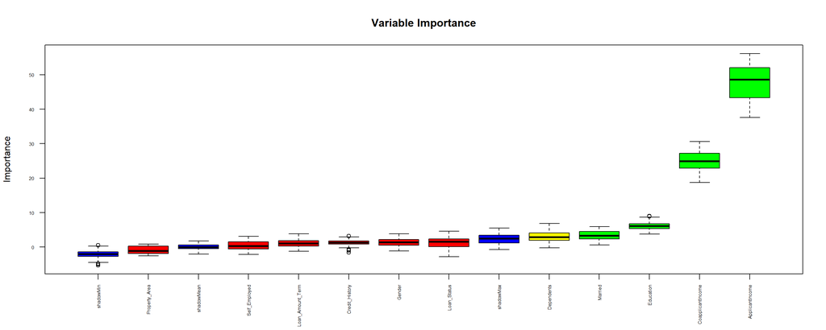

```r
plot(boruta.imp, cex.axis=.5, las=2,srt=45 ,xlab="", main="Variable Importance")
```

Lendo o Dicionário de dados

```r
dic = readxl::read_xlsx('../dados/dicionario_de_dados.xlsx')
```

Segundo o gráfico acima as variáveis de maior importância para explicar a variável **LoanAmount**, são:

```r
lz<-lapply(1:ncol(boruta.imp$ImpHistory),function(i)
                  boruta.imp$ImpHistory[is.finite(boruta.imp$ImpHistory[,i]),i])

names(lz) <- colnames(boruta.imp$ImpHistory)
Labels <- sort(sapply(lz,median), decreasing = T)
df.rank = data.frame(Importance_Vars = names(Labels), Rank = Labels, row.names = NULL)
```

Juntando as informações

```r
inner_join(df.rank,dic,by = 'Importance_Vars' )
```

| Importance_Vars | Rank | Significado |
| --- | --- | --- |
| ApplicantIncome | 48.5250677 | Renda |
| CoapplicantIncome | 24.8535859 | Renda Familiar |
| Education | 6.0889895 | Grau de Escolaridade |
| Married | 3.3020684 | Casado ou Não |
| Dependents | 2.8467843 | Quantidade de Dependentes |
| Loan_Status | 1.5450123 | Se o empréstimo foi quitado ou não |
| Gender | 1.4023253 | Gênero |
| Credit_History | 1.2977876 | Se a pessoa possui empréstimos passados |
| Loan_Amount_Term | 1.0107624 | Tempo para quitação da dívida (em dias) |
| Self_Employed | 0.3214472 | Se é autônomo |

[output cut: 1 more lines]

Me parece que neste caso a tarefa de determinar o perfil de empréstimo a um determinado cliente é significativamente mais complexa.

## 9.2 Output da Analytic Base Table

```r
write.csv(df,'../outputs/df_abt.csv')
```

Sérgio Carvalho

30 novembro, 2019